# Introduction to SimpleITKv4 Registration

SimpleITK conventions:

- Dimensionality and pixel type of registered images is required to be the same (2D/2D or 3D/3D).
- Supported pixel types are sitkFloat32 and sitkFloat64 (use the SimpleITK [Cast()](http://www.itk.org/SimpleITKDoxygen/html/namespaceitk_1_1simple.html#af8c9d7cc96a299a05890e9c3db911885) function if your image's pixel type is something else).

## Registration Components

[figure not shown]

There are many options for creating an instance of the registration framework, all of which are configured in SimpleITK via methods of the [ImageRegistrationMethod](http://www.itk.org/SimpleITKDoxygen/html/classitk_1_1simple_1_1ImageRegistrationMethod.html) class. This class encapsulates many of the components available in ITK for constructing a registration instance.

Currently, the available choices from the following groups of ITK components are:

### Optimizers

The SimpleITK registration framework supports several optimizer types via the SetOptimizerAsX() methods, these include:

- [Exhaustive](http://www.itk.org/Doxygen/html/classitk_1_1ExhaustiveOptimizerv4.html)
- [Nelder-Mead downhill simplex](http://www.itk.org/Doxygen/html/classitk_1_1AmoebaOptimizerv4.html), a.k.a. Amoeba.
- [Powell optimizer](https://itk.org/Doxygen/html/classitk_1_1PowellOptimizerv4.html).
- [1+1 evolutionary optimizer](https://itk.org/Doxygen/html/classitk_1_1OnePlusOneEvolutionaryOptimizerv4.html).
- Variations on gradient descent:
  - [GradientDescent](http://www.itk.org/Doxygen/html/classitk_1_1GradientDescentOptimizerv4Template.html)
  - [GradientDescentLineSearch](http://www.itk.org/Doxygen/html/classitk_1_1GradientDescentLineSearchOptimizerv4Template.html)
  - [RegularStepGradientDescent](http://www.itk.org/Doxygen/html/classitk_1_1RegularStepGradientDescentOptimizerv4.html)
- [ConjugateGradientLineSearch](http://www.itk.org/Doxygen/html/classitk_1_1ConjugateGradientLineSearchOptimizerv4Template.html)
- [L-BFGS-B](http://www.itk.org/Doxygen/html/classitk_1_1LBFGSBOptimizerv4.html) (Limited memory Broyden, Fletcher,Goldfarb,Shannon-Bound Constrained) - supports the use of simple constraints ($l\leq x \leq u$)

### Similarity metrics

The SimpleITK registration framework supports several metric types via the SetMetricAsX() methods, these include:

- [MeanSquares](http://www.itk.org/Doxygen/html/classitk_1_1MeanSquaresImageToImageMetricv4.html)
- [Demons](http://www.itk.org/Doxygen/html/classitk_1_1DemonsImageToImageMetricv4.html)
- [Correlation](http://www.itk.org/Doxygen/html/classitk_1_1CorrelationImageToImageMetricv4.html)
- [ANTSNeighborhoodCorrelation](http://www.itk.org/Doxygen/html/classitk_1_1ANTSNeighborhoodCorrelationImageToImageMetricv4.html)
- [JointHistogramMutualInformation](http://www.itk.org/Doxygen/html/classitk_1_1JointHistogramMutualInformationImageToImageMetricv4.html)
- [MattesMutualInformation](http://www.itk.org/Doxygen/html/classitk_1_1MattesMutualInformationImageToImageMetricv4.html)

### Interpolators

The SimpleITK registration framework supports several interpolators via the SetInterpolator() method, which receives one of the [following enumerations](http://www.itk.org/SimpleITKDoxygen/html/namespaceitk_1_1simple.html#a7cb1ef8bd02c669c02ea2f9f5aa374e5):

- sitkNearestNeighbor
- sitkLinear
- sitkBSpline
- sitkGaussian
- sitkHammingWindowedSinc
- sitkCosineWindowedSinc
- sitkWelchWindowedSinc
- sitkLanczosWindowedSinc
- sitkBlackmanWindowedSinc

```python
import SimpleITK as sitk

import nibabel as nib
import numpy as np
from matplotlib import cm

# Utility method that either downloads data from the Girder repository or
# if already downloaded returns the file name for reading from disk (cached data).
%run update_path_to_download_script
from downloaddata import fetch_data as fdata

# Always write output to a separate directory, we don't want to pollute the source directory.
import os
OUTPUT_DIR = 'Output'
```

## Utility functions

A number of utility callback functions for image display and for plotting the similarity metric during registration.

```python
import matplotlib.pyplot as plt
%matplotlib inline

from ipywidgets import interact, fixed
from IPython.display import clear_output

# Callback invoked by the interact IPython method for scrolling through the image stacks of
# the two images (moving and fixed).
def display_images(fixed_image_z, moving_image_z, fixed_npa, moving_npa):
    # Create a figure with two subplots and the specified size.
    plt.subplots(1,2,figsize=(10,8))

    # Draw the fixed image in the first subplot.
    plt.subplot(1,2,1)
    plt.imshow(fixed_npa[fixed_image_z,:,:],cmap=plt.cm.Greys_r);
    plt.title('fixed image')
    plt.axis('off')

    # Draw the moving image in the second subplot.
    plt.subplot(1,2,2)
    plt.imshow(moving_npa[moving_image_z,:,:],cmap=plt.cm.Greys_r);
    plt.title('moving image')
    plt.axis('off')

    plt.show()

# Callback invoked by the IPython interact method for scrolling and modifying the alpha blending
# of an image stack of two images that occupy the same physical space.
def display_images_with_alpha(image_z, alpha, fixed, moving):
    img = (1.0 - alpha)*fixed[:,:,image_z] + alpha*moving[:,:,image_z]
    plt.imshow(sitk.GetArrayViewFromImage(img),cmap=plt.cm.Greys_r);
    plt.axis('off')
    plt.show()

# Callback invoked when the StartEvent happens, sets up our new data.
def start_plot():
    global metric_values, multires_iterations

    metric_values = []
    multires_iterations = []

# Callback invoked when the EndEvent happens, do cleanup of data and figure.
def end_plot():
    global metric_values, multires_iterations

    del metric_values
    del multires_iterations
    # Close figure, we don't want to get a duplicate of the plot latter on.
    plt.close()

# Callback invoked when the IterationEvent happens, update our data and display new figure.
def plot_values(registration_method):
    global metric_values, multires_iterations

    metric_values.append(registration_method.GetMetricValue())
    # Clear the output area (wait=True, to reduce flickering), and plot current data
    clear_output(wait=True)
    # Plot the similarity metric values
    plt.plot(metric_values, 'r')
    plt.plot(multires_iterations, [metric_values[index] for index in multires_iterations], 'b*')
    plt.xlabel('Iteration Number',fontsize=12)
    plt.ylabel('Metric Value',fontsize=12)
    plt.show()

# Callback invoked when the sitkMultiResolutionIterationEvent happens, update the index into the
# metric_values list.
def update_multires_iterations():
    global metric_values, multires_iterations
    multires_iterations.append(len(metric_values))
```

## Initial Alignment

Use the CenteredTransformInitializer to align the centers of the two volumes and set the center of rotation to the center of the fixed image.

```python
cardiac_path='../Data/MRCardiacNii/TrainingData/'
file_list = [f for f in os.listdir(cardiac_path)  if (f.rfind('image.nii') > -1)]
```

```python
#original code 수정


path_1=str(os.path.join(cardiac_path,file_list[4]))
path_2=str(os.path.join(cardiac_path,file_list[7]))

fixed_image =  sitk.ReadImage(path_1)
moving_image = sitk.ReadImage(path_2)


interact(display_images,
         fixed_image_z=(0,fixed_image.GetSize()[2]-1),
         moving_image_z=(0,moving_image.GetSize()[2]-1),
         fixed_npa = fixed(sitk.GetArrayViewFromImage(fixed_image)),
         moving_npa=fixed(sitk.GetArrayViewFromImage(moving_image)));
```

```python
initial_transform = sitk.CenteredTransformInitializer(fixed_image,
                                                      moving_image,
                                                      sitk.Euler3DTransform(),
                                                      sitk.CenteredTransformInitializerFilter.GEOMETRY
                                                     )

moving_resampled = sitk.Resample(moving_image, fixed_image, initial_transform, sitk.sitkLinear, 0.0, moving_image.GetPixelID())

interact(display_images_with_alpha,
         image_z=(0,fixed_image.GetSize()[2]),
         alpha=(0.0,1.0,0.05),
         fixed = fixed(fixed_image),
         moving=fixed(moving_resampled));
```

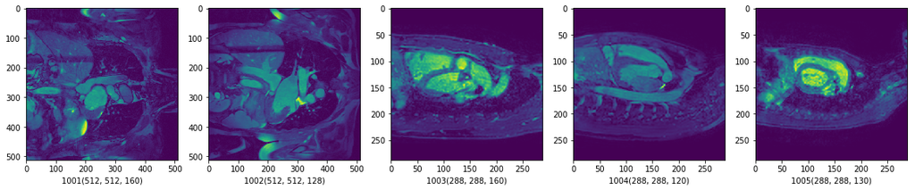

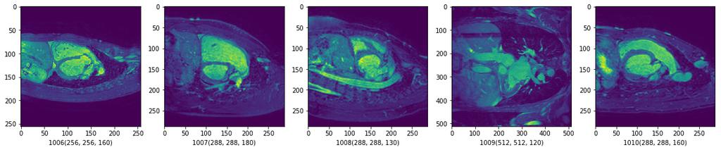

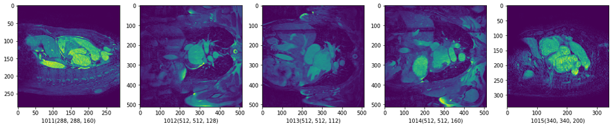

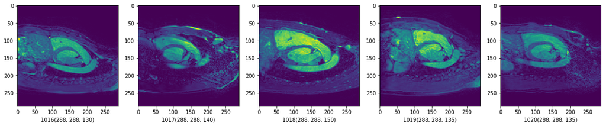

```python
#n=len(file_list)
size_arr=[]

for i in range(4):
    f, ax = plt.subplots(1,5,figsize=(20,20))
    for j in range(5):
        img = nib.load(cardiac_path+file_list[5*i+j])
        img_arr = img.get_data()
        #print(img_arr[:,:,0].shape)
        size_arr.append(img_arr[:,:,0].shape)
        img_shape = img_arr.shape
        n=int((img_arr[0][0].size/2)-1)
        #ax[j].set_ylabel(img_shape)
        x_label=str(file_list[5*i+j].split('_')[2])+str(img_shape)
        ax[j].set_xlabel(x_label)
        ax[j].imshow(img_arr[:,:,n])
```

```python
s=set(size_arr)
print(s,len(s))

print(""+str(len(file_list))+" number of total nii,"+str(len(s))+" number of case")
```

```
{(512, 512), (288, 288), (340, 340), (256, 256)} 4
20 number of total nii,4 number of case
```

### 이미지 크기 및 촬영한 axis 방향 제각각 -> 한번에 3D로 axis 하기 어려움

```
1. 4개의 set에 대해서 각각 registration 한다 -> 안됨ㅎ
2. 2D로 잘라서 -> Registation 해야할 것 같다.
```

## Registration

- Similarity metric, mutual information (Mattes MI):
  - Number of histogram bins, 50.
  - Sampling strategy, random.
  - Sampling percentage, 1%.
- Interpolator, sitkLinear.
- Optimizer, gradient descent:
  - Learning rate, step size along traversal direction in parameter space, 1.0 .
  - Number of iterations, maximal number of iterations, 100.
  - Convergence minimum value, value used for convergence checking in conjunction with the energy profile of the similarity metric that is estimated in the given window size, 1e-6.
  - Convergence window size, number of values of the similarity metric which are used to estimate the energy profile of the similarity metric, 10.

Perform registration using the settings given above, and take advantage of the built in multi-resolution framework, use a three tier pyramid.

In this example we plot the similarity metric's value during registration. Note that the change of scales in the multi-resolution framework is readily visible.

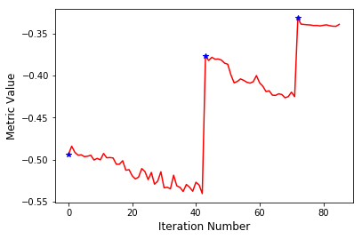

```python
registration_method = sitk.ImageRegistrationMethod()

# Similarity metric settings.
registration_method.SetMetricAsMattesMutualInformation(numberOfHistogramBins=50)
registration_method.SetMetricSamplingStrategy(registration_method.RANDOM)
registration_method.SetMetricSamplingPercentage(0.01)

registration_method.SetInterpolator(sitk.sitkLinear)

# Optimizer settings.
registration_method.SetOptimizerAsGradientDescent(learningRate=1.0, numberOfIterations=100, convergenceMinimumValue=1e-6, convergenceWindowSize=10)
registration_method.SetOptimizerScalesFromPhysicalShift()

# Setup for the multi-resolution framework.
registration_method.SetShrinkFactorsPerLevel(shrinkFactors = [4,2,1])
registration_method.SetSmoothingSigmasPerLevel(smoothingSigmas=[2,1,0])
registration_method.SmoothingSigmasAreSpecifiedInPhysicalUnitsOn()

# Don't optimize in-place, we would possibly like to run this cell multiple times.
registration_method.SetInitialTransform(initial_transform, inPlace=False)

# Connect all of the observers so that we can perform plotting during registration.
registration_method.AddCommand(sitk.sitkStartEvent, start_plot)
registration_method.AddCommand(sitk.sitkEndEvent, end_plot)
registration_method.AddCommand(sitk.sitkMultiResolutionIterationEvent, update_multires_iterations)
registration_method.AddCommand(sitk.sitkIterationEvent, lambda: plot_values(registration_method))

final_transform = registration_method.Execute(sitk.Cast(fixed_image, sitk.sitkFloat32),
                                              sitk.Cast(moving_image, sitk.sitkFloat32))
```

## Post registration analysis

Query the registration method to see the metric value and the reason the optimization terminated.

The metric value allows us to compare multiple registration runs as there is a probabilistic aspect to our registration, we are using random sampling to estimate the similarity metric.

Always remember to query why the optimizer terminated. This will help you understand whether termination is too early, either due to thresholds being too tight, early termination due to small number of iterations - numberOfIterations, or too loose, early termination due to large value for minimal change in similarity measure - convergenceMinimumValue)

```python
print('Final metric value: {0}'.format(registration_method.GetMetricValue()))
print('Optimizer\'s stopping condition, {0}'.format(registration_method.GetOptimizerStopConditionDescription()))
```

```
Final metric value: -0.3400104741583745
Optimizer's stopping condition, GradientDescentOptimizerv4Template: Convergence checker passed at iteration 14.
```

Now visually inspect the results.

```python
moving_resampled = sitk.Resample(moving_image, fixed_image, final_transform, sitk.sitkLinear, 0.0, moving_image.GetPixelID())

interact(display_images_with_alpha, image_z=(0,fixed_image.GetSize()[2]), alpha=(0.0,1.0,0.05), fixed = fixed(fixed_image), moving=fixed(moving_resampled));
```

If we are satisfied with the results, save them to file.

```python
sitk.WriteImage(moving_resampled, os.path.join(OUTPUT_DIR, 'RIRE_training_001_mr_T1_resampled.mha'))
sitk.WriteTransform(final_transform, os.path.join(OUTPUT_DIR, 'RIRE_training_001_CT_2_mr_T1.tfm'))
```